# Reporte de Analisis de Riesgo - VaR

BancoNorte - Departamento Financiero

[Sanchez Echevarria, Sebastian Alberto]

27 de Junio de 2026

==================================================================================================

1. ```
            RESUMEN EJECUTIVO
   ```

==================================================================================================

Este reporte presenta el analisis de Value at Risk (VaR) para la cartera de inversion de BancoNorte, calculado con tres metodologias estadisticas diferentes.

=== PARAMETROS DE LA CARTERA ===

```r
tickers <- c("AAPL", "MSFT", "GOOGL", "AMZN", "TSLA")
weights <- c(0.25, 0.25, 0.20, 0.20, 0.10)
confidence <- 0.95

cartera_df <- tibble(
  Activo = tickers,
  Peso = paste0(weights * 100, "%"),
  Descripcion = c(
    "Apple Inc. - Tecnologia",
    "Microsoft Corp. - Tecnologia",
    "Alphabet Inc. - Tecnologia",
    "Amazon.com Inc. - Consumo/E-commerce",
    "Tesla Inc. - Automotriz/Energia"
  )
)

cartera_df %>%
  kable(format = "html", align = c("l", "c", "l")) %>%
  kable_styling(bootstrap_options = c("striped", "hover", "condensed"), full_width = FALSE)
```

| Activo | Peso | Descripcion |
| --- | --- | --- |
| AAPL | 25% | Apple Inc. - Tecnologia |
| MSFT | 25% | Microsoft Corp. - Tecnologia |
| GOOGL | 20% | Alphabet Inc. - Tecnologia |
| AMZN | 20% | Amazon.com Inc. - Consumo/E-commerce |
| TSLA | 10% | Tesla Inc. - Automotriz/Energia |

===============================================================================================

2. ```
            DESCARGA DE DATOS
   ```

===============================================================================================

```r
fecha_inicio <- as.character(Sys.Date() - 365*2)
fecha_fin <- as.character(Sys.Date())

datos <- map(tickers, ~getSymbols(.x, from = fecha_inicio, to = fecha_fin,
                                   auto.assign = FALSE)[,6]) %>%
  reduce(merge) %>%
  `colnames<-`(tickers)

resumen_datos <- tibble(
  Activo = tickers,
  "Precio Inicial" = round(as.numeric(first(datos)), 2),
  "Precio Final" = round(as.numeric(last(datos)), 2),
  "Variacion %" = round((as.numeric(last(datos)) / as.numeric(first(datos)) - 1) * 100, 2),
  "Observaciones" = nrow(datos)
)

resumen_datos %>%
  kable(format = "html") %>%
  kable_styling(bootstrap_options = c("striped", "hover"), full_width = FALSE)
```

| Activo | Precio Inicial | Precio Final | Variacion % | Observaciones |
| --- | --- | --- | --- | --- |
| AAPL | 212.26 | 283.78 | 33.69 | 501 |
| MSFT | 445.84 | 372.97 | -16.35 | 501 |
| GOOGL | 183.99 | 337.39 | 83.37 | 501 |
| AMZN | 197.85 | 232.69 | 17.61 | 501 |
| TSLA | 197.42 | 379.71 | 92.34 | 501 |

============================================================================================

3. ```
            ANALISIS DE RETORNOS
   ```

===============================================================================================

```r
retornos <- diff(log(datos)) %>% na.omit()

stats_table <- retornos %>%
  as.data.frame() %>%
  summarise(across(everything(), list(
    Media = ~round(mean(.) * 100, 4),
    "Desv. Est." = ~round(sd(.) * 100, 4),
    Minimo = ~round(min(.) * 100, 4),
    Maximo = ~round(max(.) * 100, 4),
    "Sharpe Diario" = ~round(mean(.) / sd(.), 4)
  )))

stats_table %>%
  kable(format = "html") %>%
  kable_styling(bootstrap_options = c("striped", "hover"), full_width = TRUE)
```

| AAPL_Media | AAPL_Desv. Est. | AAPL_Minimo | AAPL_Maximo | AAPL_Sharpe Diario | MSFT_Media | MSFT_Desv. Est. | MSFT_Minimo | MSFT_Maximo | MSFT_Sharpe Diario | GOOGL_Media | GOOGL_Desv. Est. | GOOGL_Minimo | GOOGL_Maximo | GOOGL_Sharpe Diario | AMZN_Media | AMZN_Desv. Est. | AMZN_Minimo | AMZN_Maximo | AMZN_Sharpe Diario | TSLA_Media | TSLA_Desv. Est. | TSLA_Minimo | TSLA_Maximo | TSLA_Sharpe Diario |
| --- | --- | --- | --- | --- | --- | --- | --- | --- | --- | --- | --- | --- | --- | --- | --- | --- | --- | --- | --- | --- | --- | --- | --- | --- |
| 0.0581 | 1.7721 | -9.7013 | 14.2618 | 0.0328 | -0.0357 | 1.6565 | -10.5284 | 9.6525 | -0.0215 | 0.1213 | 1.9377 | -7.572 | 9.4962 | 0.0626 | 0.0324 | 2.0672 | -9.4081 | 11.3124 | 0.0157 | 0.1308 | 3.8207 | -16.7546 | 20.4491 | 0.0342 |

===== Matriz de Correlacion ========

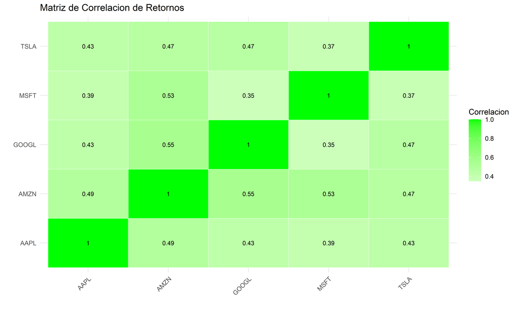

```r
cor_matrix <- cor(retornos)

cor_df <- as.data.frame(cor_matrix) %>%
  rownames_to_column("Activo") %>%
  pivot_longer(-Activo, names_to = "Par", values_to = "Correlacion")

ggplot(cor_df, aes(x = Activo, y = Par, fill = Correlacion)) +
  geom_tile(color = "white") +
  geom_text(aes(label = round(Correlacion, 2)), color = "black", size = 3) +
  scale_fill_gradient2(low = "red", mid = "white", high = "green", midpoint = 0) +
  labs(title = "Matriz de Correlacion de Retornos", x = "", y = "") +
  theme_minimal() +
  theme(axis.text.x = element_text(angle = 45, hjust = 1))
```

===============================================================================================

4. ```
            CALCULO DE VaR
   ```

4.1. Metodo Parametrico (Varianza - Covarianza)

===============================================================================================

```r
var_param <- calcular_var(
  tickers = tickers,
  weights = weights,
  confidence = confidence,
  method = "parametric",
  periodo_inicio = fecha_inicio,
  periodo_fin = fecha_fin
)

resultado_param <- tibble(
  Metrica = c("VaR Diario", "VaR 10 dias", "Confianza", "Volatilidad Cartera"),
  Valor = c(
    paste0(round(var_param$var_diario * 100, 4), "%"),
    var_param$var_10d_pct,
    paste0(confidence * 100, "%"),
    paste0(round(var_param$detalles_metodo$volatilidad_cartera * 100, 4), "%")
  )
)

resultado_param %>%
  kable(format = "html") %>%
  kable_styling(bootstrap_options = c("striped", "hover"), full_width = FALSE)
```

| Metrica | Valor |
| --- | --- |
| VaR Diario | 2.4587% |
| VaR 10 dias | 7.775% |
| Confianza | 95% |
| Volatilidad Cartera | 1.5248% |

======================================================================================

4.2. METODO HISTORICO

=========================================================================================

```r
var_hist <- calcular_var(
  tickers = tickers,
  weights = weights,
  confidence = confidence,
  method = "historical",
  periodo_inicio = fecha_inicio,
  periodo_fin = fecha_fin
)

resultado_hist <- tibble(
  Metrica = c("VaR Diario", "VaR 10 dias", "Confianza", "Observaciones"),
  Valor = c(
    paste0(round(var_hist$var_diario * 100, 4), "%"),
    var_hist$var_10d_pct,
    paste0(confidence * 100, "%"),
    var_hist$detalles_metodo$n_observaciones
  )
)

resultado_hist %>%
  kable(format = "html") %>%
  kable_styling(bootstrap_options = c("striped", "hover"), full_width = FALSE)
```

| Metrica | Valor |
| --- | --- |
| VaR Diario | 2.494% |
| VaR 10 dias | 7.8866% |
| Confianza | 95% |
| Observaciones | 500 |

==================================================================================

4.3. METODO MONTE CARLO (10,000 SIMULACIONES)

=========================================================================================

```r
var_mc <- calcular_var(
  tickers = tickers,
  weights = weights,
  confidence = confidence,
  method = "montecarlo",
  n_sim = 10000,
  periodo_inicio = fecha_inicio,
  periodo_fin = fecha_fin
)

resultado_mc <- tibble(
  Metrica = c("VaR Diario", "VaR 10 dias", "Confianza", "Simulaciones", "Media Simulada"),
  Valor = c(
    paste0(round(var_mc$var_diario * 100, 4), "%"),
    var_mc$var_10d_pct,
    paste0(confidence * 100, "%"),
    format(var_mc$detalles_metodo$n_simulaciones, big.mark = ","),
    paste0(round(var_mc$detalles_metodo$media_simulada * 100, 4), "%")
  )
)

resultado_mc %>%
  kable(format = "html") %>%
  kable_styling(bootstrap_options = c("striped", "hover"), full_width = FALSE)
```

[output not shown]

==================================================================================================

5. COMPARACIÓN DE METODOS

=========================================================================================

```r
comparacion <- tibble(
  Metodo = c("Parametrico", "Historico", "Monte Carlo"),
  "VaR Diario" = c(
    paste0(round(var_param$var_diario * 100, 4), "%"),
    paste0(round(var_hist$var_diario * 100, 4), "%"),
    paste0(round(var_mc$var_diario * 100, 4), "%")
  ),
  "VaR 10 dias" = c(var_param$var_10d_pct, var_hist$var_10d_pct, var_mc$var_10d_pct),
  Supuestos = c(
    "Distribucion normal",
    "Datos historicos representativos",
    "Modelo de correlacion correcto"
  ),
  "Uso Recomendado" = c(
    "Carteras diversificadas, volatilidad estable",
    "Datos suficientes (2+ anos)",
    "Carteras complejas, stress testing"
  )
)

comparacion %>%
  kable(format = "html") %>%
  kable_styling(bootstrap_options = c("striped", "hover"), full_width = TRUE) %>%
  row_spec(0, bold = TRUE, background = "#1F4E79", color = "white")
```

| Metodo | VaR Diario | VaR 10 dias | Supuestos | Uso Recomendado |
| --- | --- | --- | --- | --- |
| Parametrico | 2.4587% | 7.775% | Distribucion normal | Carteras diversificadas, volatilidad estable |
| Historico | 2.494% | 7.8866% | Datos historicos representativos | Datos suficientes (2+ anos) |
| Monte Carlo | 2.4469% | 7.7376% | Modelo de correlacion correcto | Carteras complejas, stress testing |

==================================================================================================

6. VISUALIZACION DE DISTRIBUCIONES

=========================================================================================

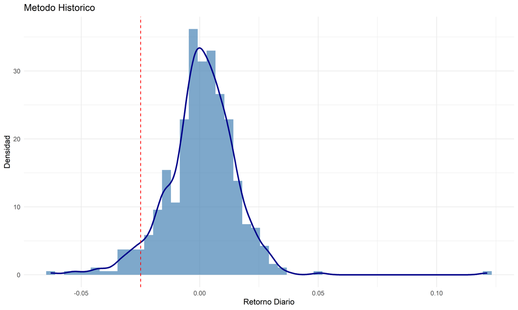

```r
ret_cartera <- as.matrix(retornos) %*% weights

p1 <- ggplot(tibble(retorno = as.vector(ret_cartera)), aes(x = retorno)) +
  geom_histogram(aes(y = after_stat(density)), bins = 50, fill = "steelblue", alpha = 0.7) +
  geom_density(color = "darkblue", linewidth = 1) +
  geom_vline(xintercept = -var_hist$var_diario, color = "red", linetype = "dashed") +
  labs(title = "Metodo Historico", x = "Retorno Diario", y = "Densidad") +
  theme_minimal()

sim_data <- tibble(retorno = var_mc$detalles_metodo$escenarios)
p2 <- ggplot(sim_data, aes(x = retorno)) +
  geom_histogram(aes(y = after_stat(density)), bins = 50, fill = "darkgreen", alpha = 0.7) +
  geom_density(color = "green4", linewidth = 1) +
  geom_vline(xintercept = -var_mc$var_diario, color = "red", linetype = "dashed") +
  labs(title = "Metodo Monte Carlo", x = "Retorno Diario", y = "Densidad") +
  theme_minimal()

p1
```

==================================================================================================

7. CONCLUSIONES Y RECOMENDACIONES

=========================================================================================

Recomendaciones:

Revisar la cartera mensualmente con el metodo historico para detectar cambios en la distribucion de retornos.

Usar Monte Carlo para stress testing ante eventos extremos (black swan).

Considerar el Expected Shortfall (CVaR) como complemento al VaR para medir perdidas en la cola.